# Data Viz

Drawn from Fundamentals of Data Visualization by Claus O. Wilke

### Ugly, bad, and wrong figures

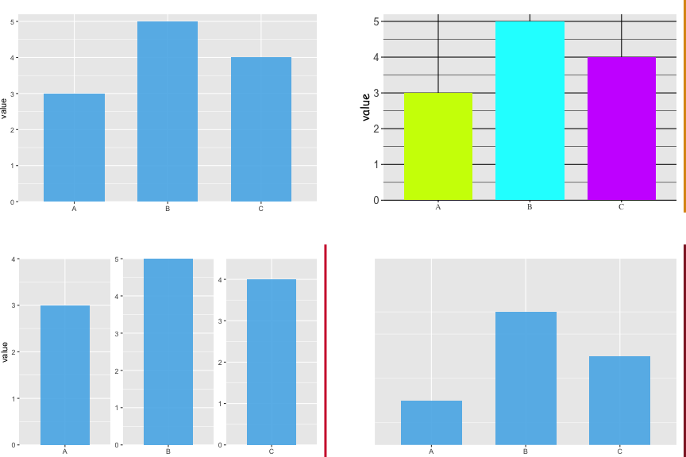

### 3D figures are confusing

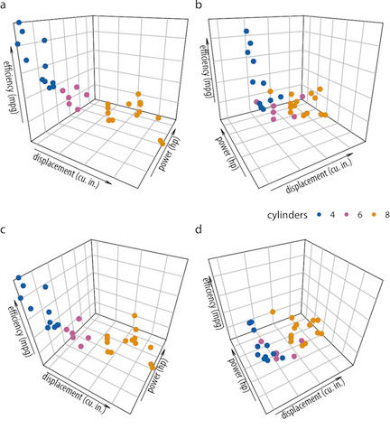

### Representing multi-dimensional data

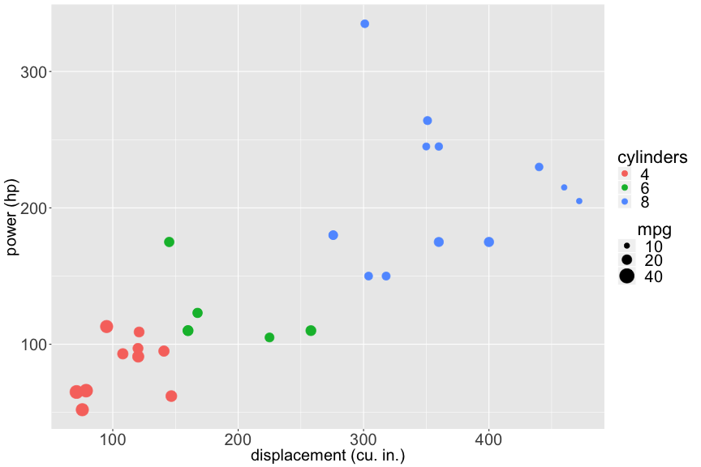

### Make things readable

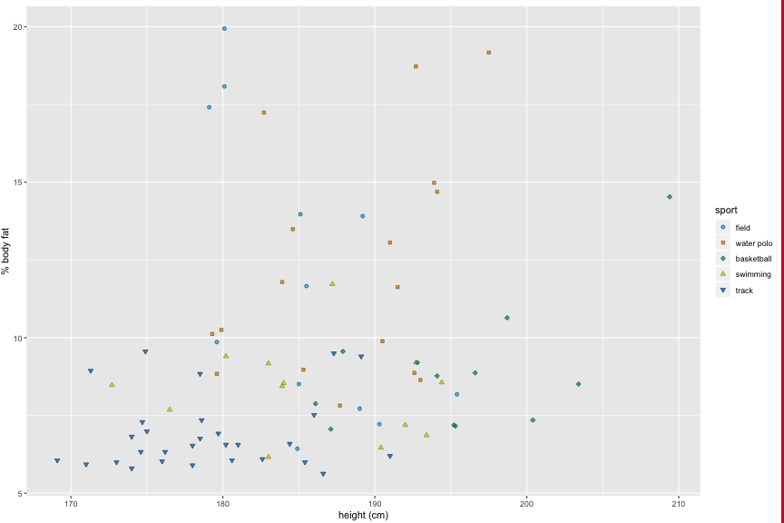

### Make things readable

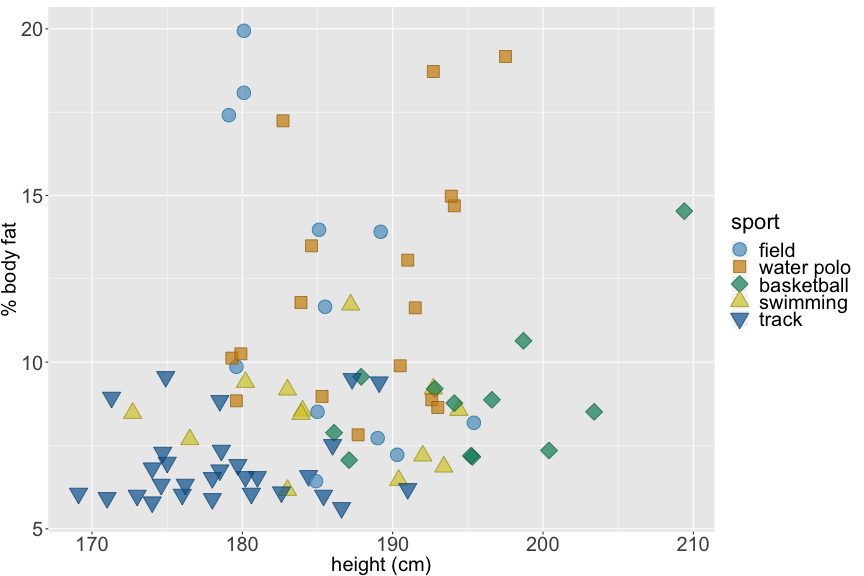

### Make things easy

If there is a clear visual ordering in your data, make sure to match it in the legend.

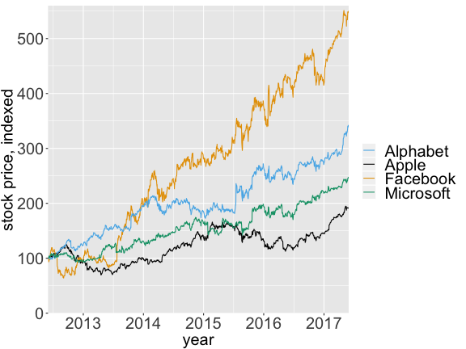

### Make things easy

If there is a clear visual ordering in your data, make sure to match it in the legend.

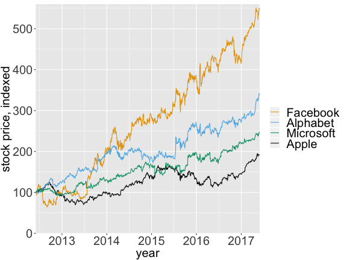

### Make things easy

Show the patterns and no extraneous information

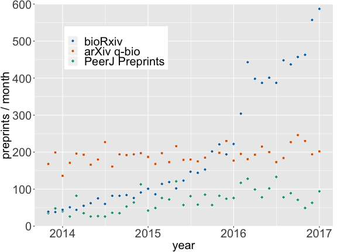

### Make things easy

Show the patterns and no extraneous information

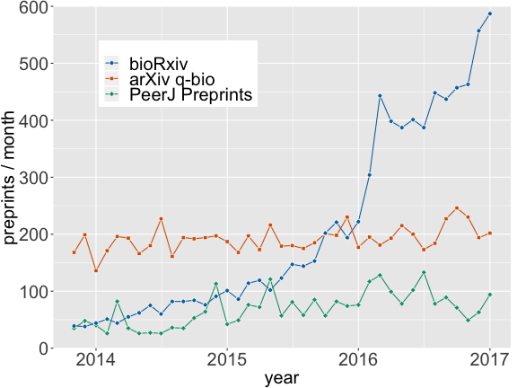

### Make things easy

Show the patterns and no extraneous information

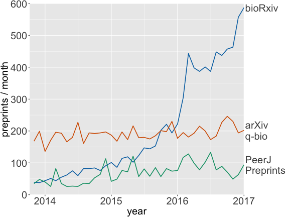

### Qualitative Color Scales

Recommended: Okabe Ito, ColorBrewer Dark2, ggplot2 hue

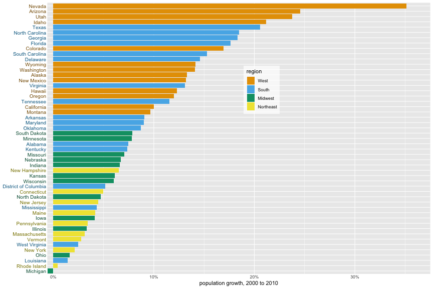

Recommended: Colorbrewer Blues, Heat, Viridis

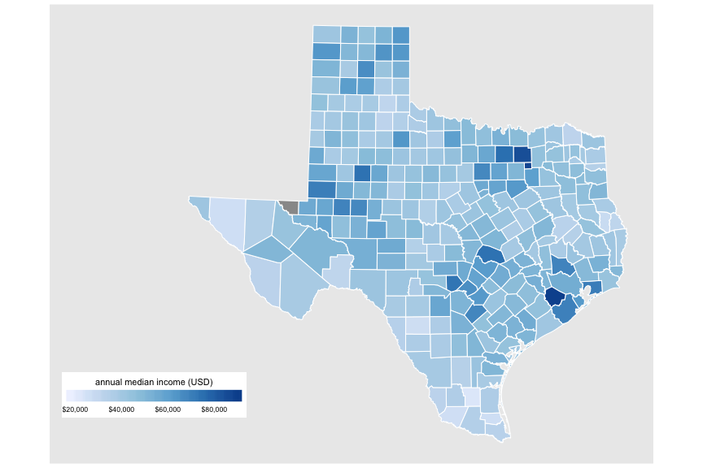

### Diverging color scales

Recommended: CARTO Earth, ColorBrewer PiYG, Blue-Red

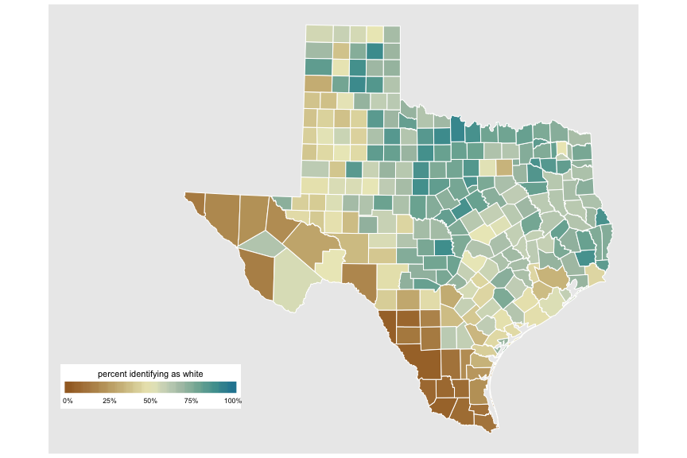

### Adding highlights

Recommended: Okabe Ito Accent, Grays with accent, ColorBrewer Accent

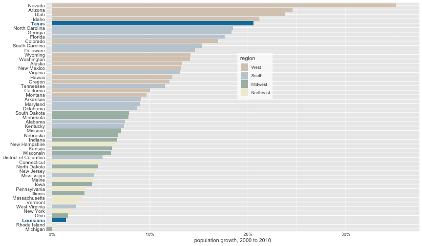

### Use color for a purpose

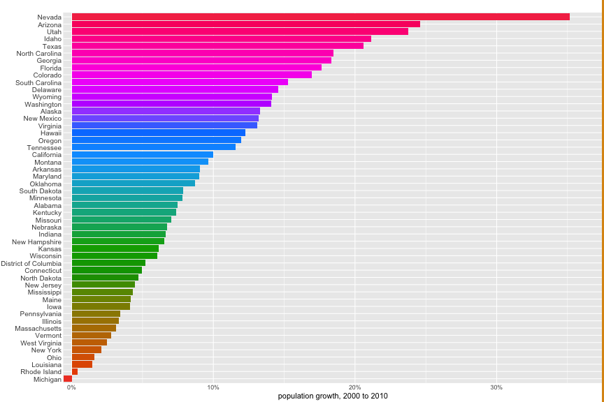

### Make sure it grayscales

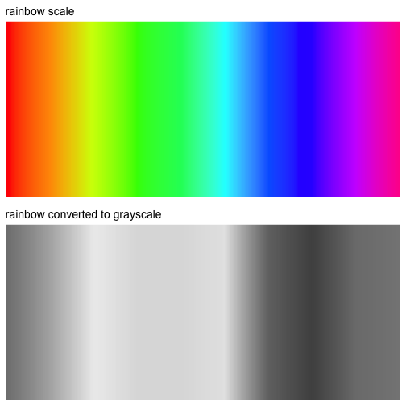

### Don't include too much information

Use qualitative color scales for three to five different categories

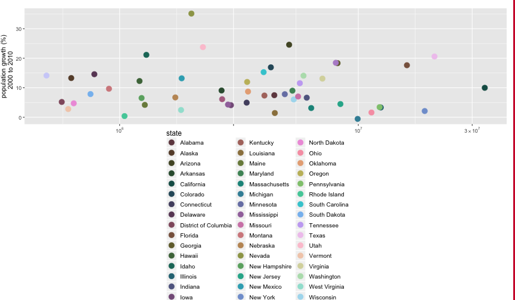

### Consider color deficiencies: sequential scale

A properly designed sequential scale (e.g. Heat) presents a continuous gradient from dark to light colors

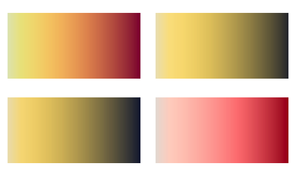

### Consider color deficiencies: diverging scales

Popular color contrasts in diverging scales can become indistinguishable for some forms of color-vision deficiency. ColorBrewer PiYG (pink to yellow-green) works for all forms of color-vision deficiency.

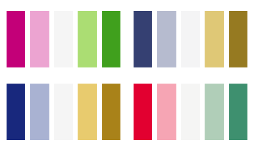

### Consider color deficiencies: qualitative scales

Qualitative scales (e.g. Okabe Ito) require that many different colors are distinguishable from each other under all forms of cvd.

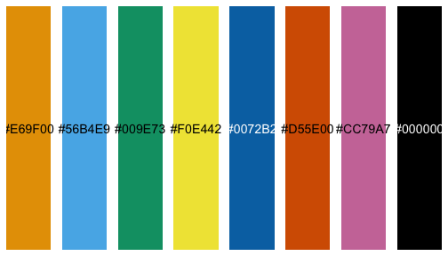

### Visualizing uncertainty

Error bars don't represent the variation within each category or the uncertainty of the sample means well.

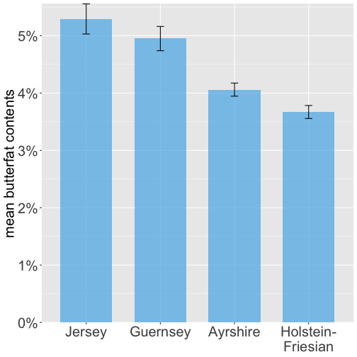

### Visualizing uncertainty

Kernel density plots help to visualize several distributions at once.

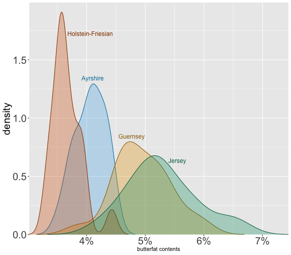

### Consider what you want to communicate

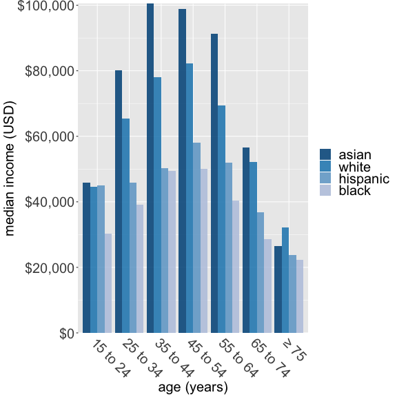

### Consider what you want to communicate

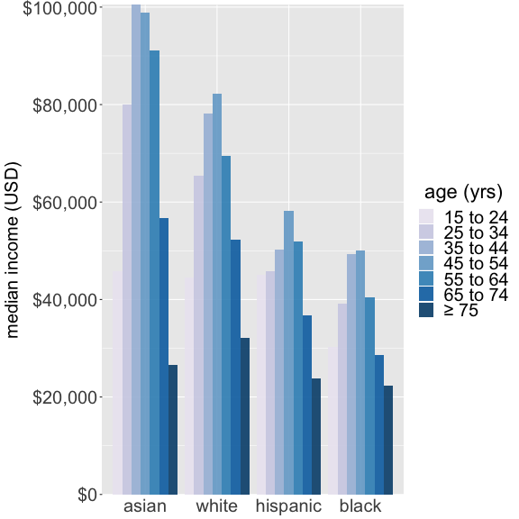